# Exercise 4_1: OSM Data

Geodata & Spatial Regression

Author

Anne-Kathrin Stroppe, Dennis Abel

### Exercises

**Note🏋 Exercise 1**

Pick a city of the world to your liking and retrieve its bounding box. Then plot it: What do you see?

**Caution💡 Tip**

The function you may search for is part of the `osmdata` package. Have a look at the slides.

**Note🏋 Exercise 2**

Please choose a couple of building types you are interested in and set them as key and value pairs. You can find a list of building types in the [Overpass API documentation](https://wiki.openstreetmap.org/wiki/Key:building). But don’t forget to set the timeout query parameters using the `osmdata::opq()` function first.

**Caution💡 Tip**

First, specify the bounding box like before; second, the query parameters; and third, the key and value pairs. Try using a pipe workflow, as it makes it easier.

**Note🏋 Exercise 3**

Download the data using the `osmdata::osmdata_sf()` function and extract only the polygons.

**Caution💡 Tip**

The downloaded data is a list. The polygons are a named list element that you can extract with its name `osm_polygons`, just like a variable in a data table.

**Note🏋 Exercise 4**

Take some time to browse through the data. Depending on your chosen building type, you may find some interesting information. You can also plot the data you have just downloaded.

**Caution💡 Tip**

You may consider converting the data into a tibble using `tibble::as_tibble()` and maybe a `sf::st_as_sf()` afterward for a nicer browsing experience.

### Solutions

**Tip✅ Solution 1**

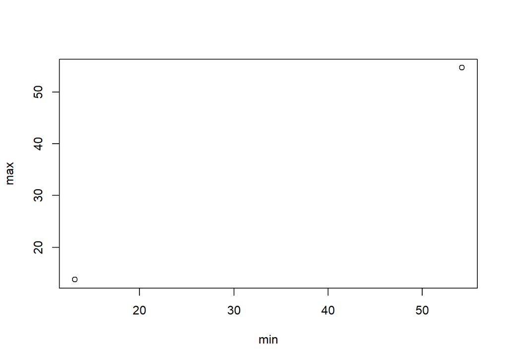

```r
ruegen <- osmdata::getbb("Rügen")

plot(ruegen)
```

```r
# We see two points, which build the extremes of the bounding box.
```

**Tip✅ Solution 2**

```r
ruegen <-
  osmdata::getbb("Rügen") |>
  osmdata::opq(timeout = 25) |>
  osmdata::add_osm_feature(
    key = "building",
    value = c("house", "residential", "apartments", "detached", "bungalow")
  )
```

**Tip✅ Solution 3**

```r
osmdata::set_overpass_url("https://overpass-api.de/api/interpreter")

ruegen <-
  osmdata::getbb("Rügen") |>
  osmdata::opq(timeout = 25) |>
  osmdata::add_osm_feature(
    key = "building",
    value = c("house", "residential", "apartments", "detached", "bungalow")
  ) |>
  osmdata::osmdata_sf()

ruegen <- ruegen$osm_polygons
```

**Tip✅ Solution 4**

```r
library(ggplot2)
library(patchwork)

ruegen <-
  ruegen |>
  tibble::as_tibble() |>
  sf::st_as_sf()

ruegen
```

```
Simple feature collection with 4838 features and 89 fields
Geometry type: POLYGON
Dimension:     XY
Bounding box:  xmin: 13.11521 ymin: 54.22811 xmax: 13.75383 ymax: 54.68018
Geodetic CRS:  WGS 84
# A tibble: 4,838 × 90
   osm_id   name              abandoned `addr:city` `addr:country` `addr:hamlet`
   <chr>    <chr>             <chr>     <chr>       <chr>          <chr>
 1 28430840 <NA>              <NA>      <NA>        <NA>           <NA>
 2 29418125 <NA>              <NA>      <NA>        <NA>           <NA>
 3 29418219 Koloss von Prora… <NA>      <NA>        <NA>           <NA>
 4 30151636 <NA>              <NA>      Mönchgut    DE             <NA>
 5 30151653 <NA>              <NA>      Mönchgut    DE             <NA>
 6 31144258 <NA>              <NA>      <NA>        <NA>           <NA>
 7 38657041 <NA>              <NA>      Bergen auf… DE             <NA>
 8 39839282 <NA>              <NA>      <NA>        <NA>           <NA>
 9 39839294 <NA>              <NA>      <NA>        <NA>           <NA>
10 42451069 <NA>              <NA>      <NA>        <NA>           <NA>
# ℹ 4,828 more rows
# ℹ 84 more variables: `addr:housename` <chr>, `addr:housenumber` <chr>,
#   `addr:place` <chr>, `addr:postcode` <chr>, `addr:street` <chr>,
#   `addr:suburb` <chr>, air_conditioning <chr>, alt_name <chr>, amenity <chr>,
#   architect <chr>, `architect:wikidata` <chr>, beds <chr>, building <chr>,
#   `building:architecture` <chr>, `building:colour` <chr>,
#   `building:flats` <chr>, `building:levels` <chr>, …
```

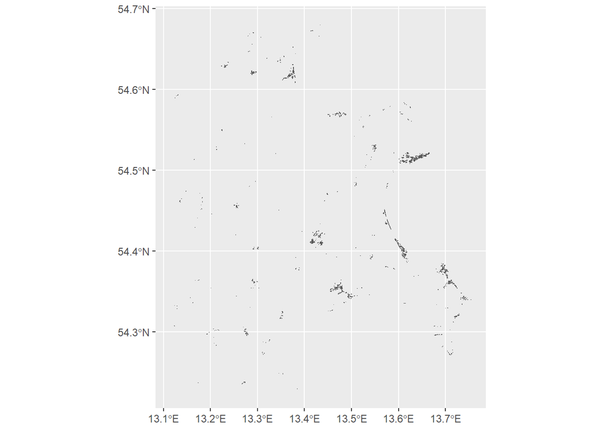

```r
ggplot() +
  geom_sf(data = ruegen)
```